# Reproducible research- Project1

**Author: TIMITE ALY**

## Setting working directory and data importing__

```r
 library(tidyverse)
 setwd("C:/Users/Ali TIMITE/Downloads/data science/5-Reproducible research/semaine2/repdata_data_activity")
 activity <- read.csv("activity.csv", sep=",")
```

### Histogram of the total number of steps taken each day

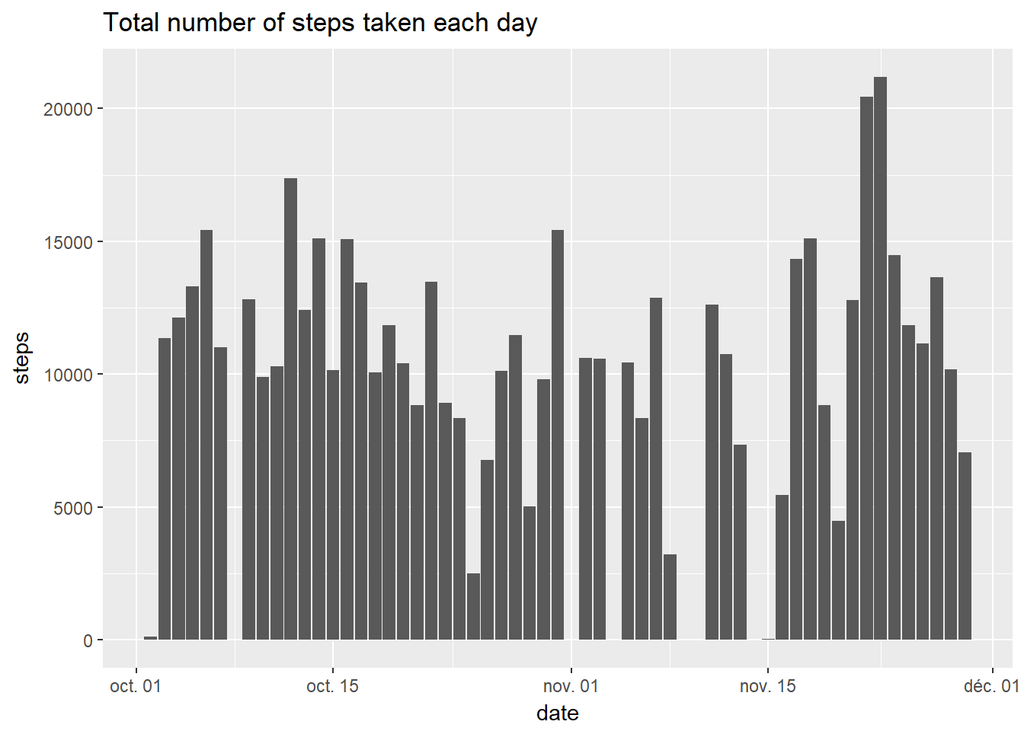

```r
activity1 <- aggregate(steps~date, activity, sum)
activity1$date <- as.Date(activity1$date, format="%Y-%m-%d")
h <- ggplot(activity1, aes(x=date, y=steps))+geom_histogram(stat = "identity")+ggtitle("Total number of steps taken each day")
print(h)
```

**Mean and median of steps taken each day**

```r
Mean <- aggregate(steps~date, activity, mean)
Median <- aggregate(steps~date, activity, median)

Mean_eachday <- mean(Mean$steps)
Median_eachday <- median(Median$steps)
```

Mean of steps taken each day is **37.3825996**, and median is **0**

## Time series plot of the average number of steps taken

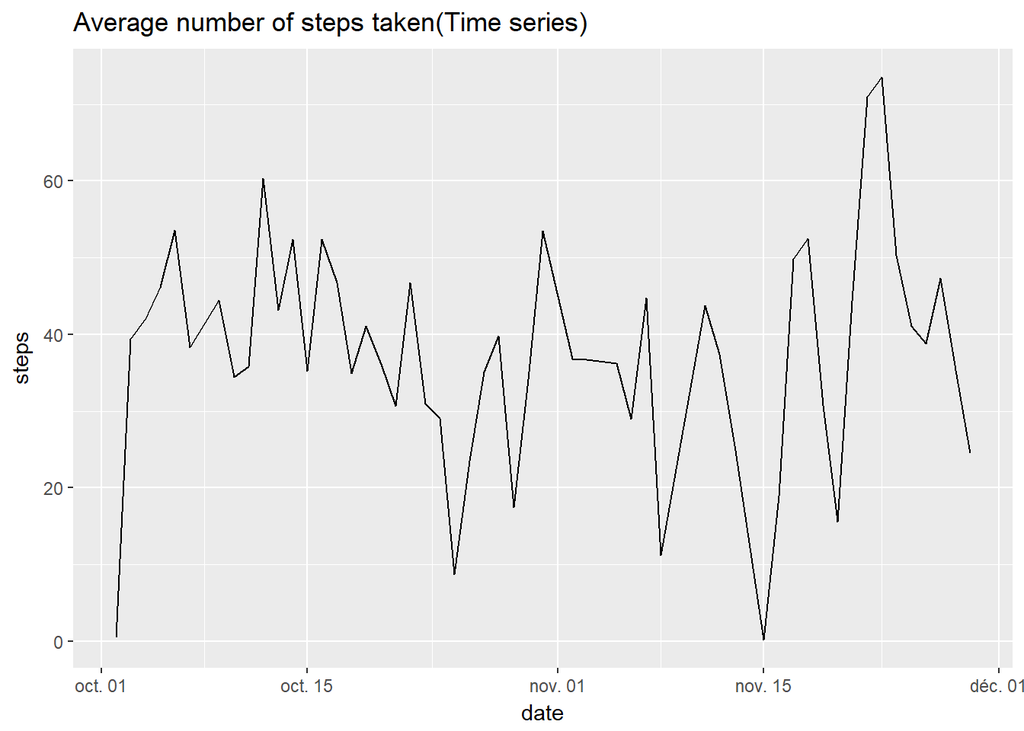

```r
Mean$date <- as.Date(Mean$date, format="%Y-%m-%d")

h2 <- ggplot(Mean, aes(x=date, y=steps))+geom_line(stat = "identity")+ ggtitle("Average number of steps taken(Time series)")

print(h2)
```

### 5 minutes interval containing Maximum number of steps

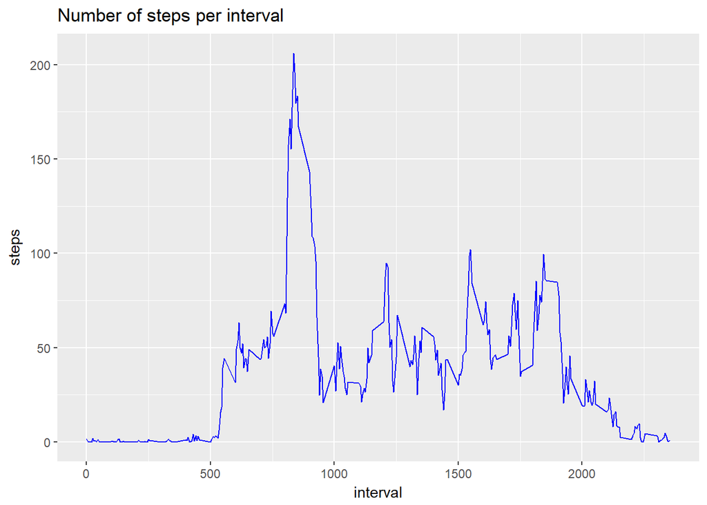

```r
activity4 <- aggregate(steps~interval, activity, mean)
maximum <- filter(activity4, steps == max(steps))
maximum_time <- maximum[1,1]
h4 <- ggplot(activity4, aes(x=interval, y=steps))+geom_line(stat = "identity", color="blue" )+ ggtitle("Number of steps per interval")
print(h4)
```

The 5-minute interval that, on average, contains the maximum number of steps is around 835th. minutes

## Imputing missing data

Let us count the number of missing values

```r
numMissingValues <- length(which(is.na(activity$steps)))
```

There are 2304 missing values

To fill each missing value, we’ll replace each one by the mean steps of existing values in activity vector

```r
activityDataImputed <- activity
activityDataImputed$steps[is.na(activityDataImputed$steps)] <- mean(activityDataImputed$steps[!is.na(activityDataImputed$steps)])
```

**Histogram of the total number of steps taken each day**

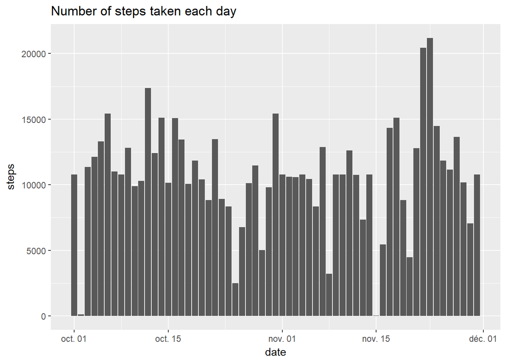

```r
activityDataImputed$date <- as.Date(activityDataImputed$date, format="%Y-%m-%d")

h5 <- ggplot(activityDataImputed, aes(x=date, y=steps))+geom_histogram(stat = "identity") + ggtitle("Number of steps taken each day")
print(h5)
```

**For the final comparison, we’ll use activityDtatImputed as final vector**

```r
activityfinal <- activityDataImputed
```

**Convert activityfinal date variable as date format and transform it as weekdays**

```r
activityfinal$date <- as.Date(activityfinal$date , format="%Y-%m-%d")
activityfinal$date <- weekdays(activityfinal$date)
```

**Subsetting week-end days and ordinary week days**

```r
activity_wkd <- subset(activityfinal, activityfinal$date=="samedi" | activityfinal$date=="dimanche")
activity_wday <- subset(activityfinal, activityfinal$date!="samedi" & activityfinal$date!="dimanche")
```

**Find everyday mean for each vector**

```r
activity_wday_mean <- aggregate(steps~date, activity_wday, mean)
activity_wkd_mean <- aggregate(steps~date, activity_wkd, mean)
```

**Add a type variable for each vector(weekend or weekday)**

```r
f_activity_wkd_mean <- cbind(activity_wkd_mean, "type"= rep("weekend",2))
f_activity_wday_mean <- cbind(activity_wday_mean, "type"= rep("weekday",5))
```

**Binding f_activity_wkd_mean and f_activity_wday_mean**

```r
final_week_activity <- rbind(f_activity_wday_mean, f_activity_wkd_mean)
```

**classifying weekdays in order**

```r
final_week_activity$date <- factor(final_week_activity$date,levels= c("lundi","mardi","mercredi", "jeudi","vendredi","samedi",'dimanche'))
final_week_activity <- final_week_activity[order(final_week_activity$date),]
```

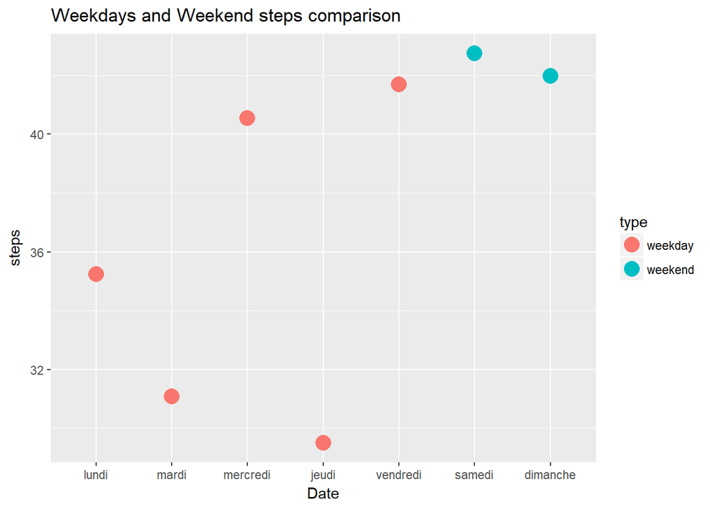

```r
h8 <- ggplot(final_week_activity, aes(date, steps, col= type)) + geom_point(size= 5) + xlab("Date")+ylab("steps")+ggtitle("Weekdays and Weekend steps comparison")
print(h8)
```